# Mid-Term Project | Group -5

Group Members-

Subrata Das (243000661)

Wasim Kabir (243002561)

Mafia Rahman Tule (243001461)

Mohammad Helal Uddin (243002461)

Fahim Shahriar Chowdhury (243000561)

Last compiled on: 05 December, 2024

# 1 BACK GROUND

A health insurance company’s financial success relies on generating more revenue than it incurs cost on the healthcare of its policyholders. However, forecasting medical expenses is challenging due to the unpredictability of costs associated with rare conditions. This project aims to precisely predict insurance costs by analyzing individuals’ data, such as age, Body Mass Index, smoking habits, and other factors. Furthermore, we will identify the key variable that has the most significant impact on insurance costs. These predictions can be utilized to develop actuarial tables, enabling the adjustment of yearly premiums based on anticipated treatment expenses. This essentially constitutes a regression problem.

# 2 DATASET

In this project, the dataset is already separated randomly into train and test dataset.

The features in the dataset are:

1. **age**: age of primary beneficiary.
2. **sex**: insurance contractor gender, female, male.
3. **bmi**: Body Mass Index, providing an understanding of body, weights that are relatively high or low relative to height, objective index of body weight (kg/m2) using the ratio of height to weight, ideally 18.5 to 24.9.
4. **children**: number of children covered by health insurance / number of dependents.
5. **smoker**: smoking or not.
6. **region**: the beneficiary’s residential area in the US, northeast, southeast, southwest, northwest.
7. **charges**: individual medical costs billed by health insurance.

Since we are predicting insurance costs, charges will be our target feature.

```r
# Load required libraries
library(ggplot2)
library(Metrics)
library(car)
library(corrplot)
library(dplyr)
library(tidyr)
```

```r
# Load training and testing datasets
train_data <- read.csv("train.csv")
test_data <- read.csv("test.csv")

# Display basic information about the datasets
cat("Training Dataset Dimensions:", dim(train_data)[1], "rows,", dim(train_data)[2], "columns\n")
```

```
## Training Dataset Dimensions: 1070 rows, 7 columns
```

```r
cat("Testing Dataset Dimensions:", dim(test_data)[1], "rows,", dim(test_data)[2], "columns\n")
```

```
## Testing Dataset Dimensions: 268 rows, 7 columns
```

# 3 EXPECTED TASK

## 3.1 Data Preparation [Training Dataset] [Marks: 05]

First, we are examining and preparing our training data:

### 3.1.1 Check if each feature is already in correct data type. If not set the correct data type.

```r
glimpse(train_data)
```

```
## Rows: 1,070
## Columns: 7
## $ age      <int> 37, 18, 23, 32, 58, 25, 36, 34, 53, 45, 20, 60, 58, 34, 60, 1…
## $ sex      <chr> "male", "male", "female", "male", "female", "female", "male",…
## $ bmi      <dbl> 34.100, 34.430, 36.670, 35.200, 32.395, 26.790, 35.200, 33.25…
## $ children <int> 4, 0, 2, 2, 1, 2, 1, 1, 0, 5, 1, 1, 0, 0, 0, 0, 1, 3, 5, 1, 1…
## $ smoker   <chr> "yes", "no", "yes", "no", "no", "no", "yes", "no", "no", "no"…
## $ region   <chr> "southwest", "southeast", "northeast", "southwest", "northeas…
## $ charges  <dbl> 40182.246, 1137.470, 38511.628, 4670.640, 13019.161, 4189.113…
```

we can see above that each feature is already in its correct type

### 3.1.2 Check if there are any duplicated observations on train dataset. If there’s then drop the row.

```r
train_data[duplicated(train_data), ]
```

```
##     age  sex   bmi children smoker    region  charges
## 268  19 male 30.59        0     no northwest 1639.563
```

** There is one duplication **

```r
#We are dropping the duplicate row.
train_data <- train_data %>% distinct()
```

** We have dropped the duplicate row.**

### 3.1.3 Inspect for missing value. If there’s any missing value, please perform appropriate treatment.

```r
# Checking for missing values
missing_values <- colSums(is.na(train_data))
print(missing_values)
```

```
##      age      sex      bmi children   smoker   region  charges
##        0        0        0        0        0        0        0
```

```r
# Converting categorical variables to factors
train_data$sex <- as.factor(train_data$sex)
train_data$smoker <- as.factor(train_data$smoker)
train_data$region <- as.factor(train_data$region)

# Displaying structure of the prepared data
str(train_data)
```

```
## 'data.frame':    1069 obs. of  7 variables:
##  $ age     : int  37 18 23 32 58 25 36 34 53 45 ...
##  $ sex     : Factor w/ 2 levels "female","male": 2 2 1 2 1 1 2 1 2 2 ...
##  $ bmi     : num  34.1 34.4 36.7 35.2 32.4 ...
##  $ children: int  4 0 2 2 1 2 1 1 0 5 ...
##  $ smoker  : Factor w/ 2 levels "no","yes": 2 1 2 1 1 1 2 1 1 1 ...
##  $ region  : Factor w/ 4 levels "northeast","northwest",..: 4 3 1 4 1 2 3 1 3 3 ...
##  $ charges : num  40182 1137 38512 4671 13019 ...
```

No missing values found

## 3.2 Exploratory Data Analysis (EDA) [Training Dataset] [Marks: 08]

### 3.2.1 Show the descriptive statistics of training dataset. Explain the numeric & categorical features.

```r
# Summary statistics
# Basic statistics of charges
charges_stats <- summary(train_data$charges)
print("Summary Statistics:")
```

```
## [1] "Summary Statistics:"
```

```r
print(summary(train_data))
```

```
##       age            sex           bmi           children    smoker
##  Min.   :18.00   female:543   Min.   :15.96   Min.   :0.00   no :850
##  1st Qu.:26.00   male  :526   1st Qu.:26.32   1st Qu.:0.00   yes:219
##  Median :39.00                Median :30.40   Median :1.00
##  Mean   :39.11                Mean   :30.73   Mean   :1.08
##  3rd Qu.:51.00                3rd Qu.:34.80   3rd Qu.:2.00
##  Max.   :64.00                Max.   :53.13   Max.   :5.00
##        region       charges
##  northeast:249   Min.   : 1122
##  northwest:253   1st Qu.: 4747
##  southeast:294   Median : 9447
##  southwest:273   Mean   :13212
##                  3rd Qu.:16586
##                  Max.   :63770
```

```r
print("Charges Statistics:")
```

```
## [1] "Charges Statistics:"
```

```r
print(charges_stats)
```

```
##    Min. 1st Qu.  Median    Mean 3rd Qu.    Max.
##    1122    4747    9447   13212   16586   63770
```

### 3.2.2 Show the distribution of ‘Charges’ through appropriate plot. Explain the plot.

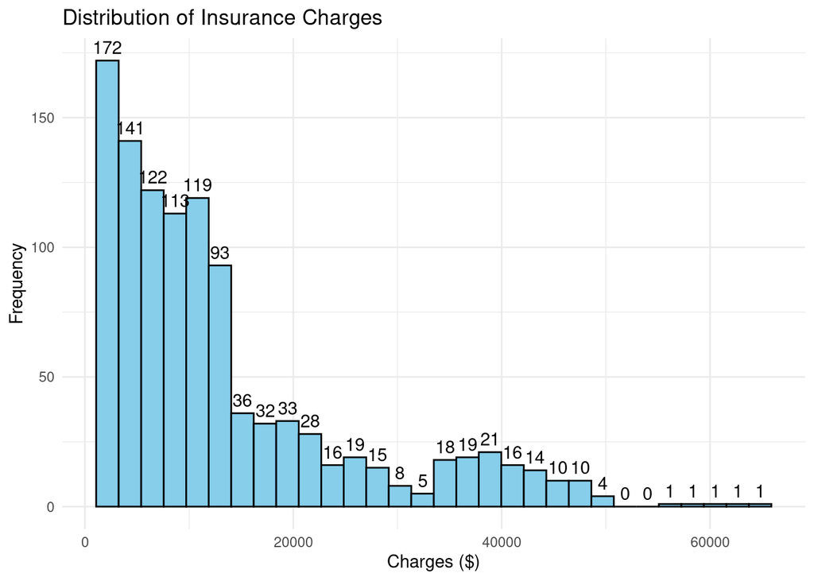

```r
# Plot distribution of charges
ggplot(train_data, aes(x = charges)) +
  geom_histogram(fill = "skyblue", bins = 30, color = "black") +
  stat_bin(geom = "text", bins = 30, aes(label = ..count..),
           vjust = -0.5, color = "black") +
  theme_minimal() +
  labs(title = "Distribution of Insurance Charges",
       x = "Charges ($)",
       y = "Frequency")
```

The distribution of charges shows a right-skewed pattern, with most charges concentrated in the lower range but with significant high-cost outliers.

### 3.2.3 Create below boxplots. And explain if there’s any pattern.

#### 3.2.3.1 Boxplot of Medical Charges as per sex.

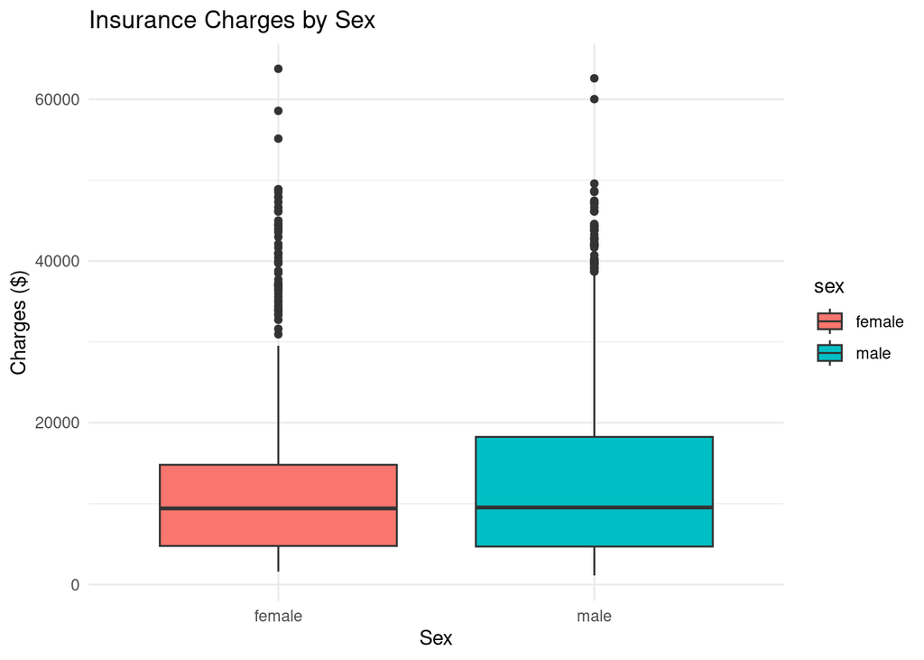

```r
# Sex vs Charges
ggplot(train_data, aes(x = sex, y = charges, fill = sex)) +
  geom_boxplot() +
  theme_minimal() +
  labs(title = "Insurance Charges by Sex",
       x = "Sex",
       y = "Charges ($)")
```

Gender differences are relatively minor

#### 3.2.3.2 Boxplot of Medical Charges as per region.

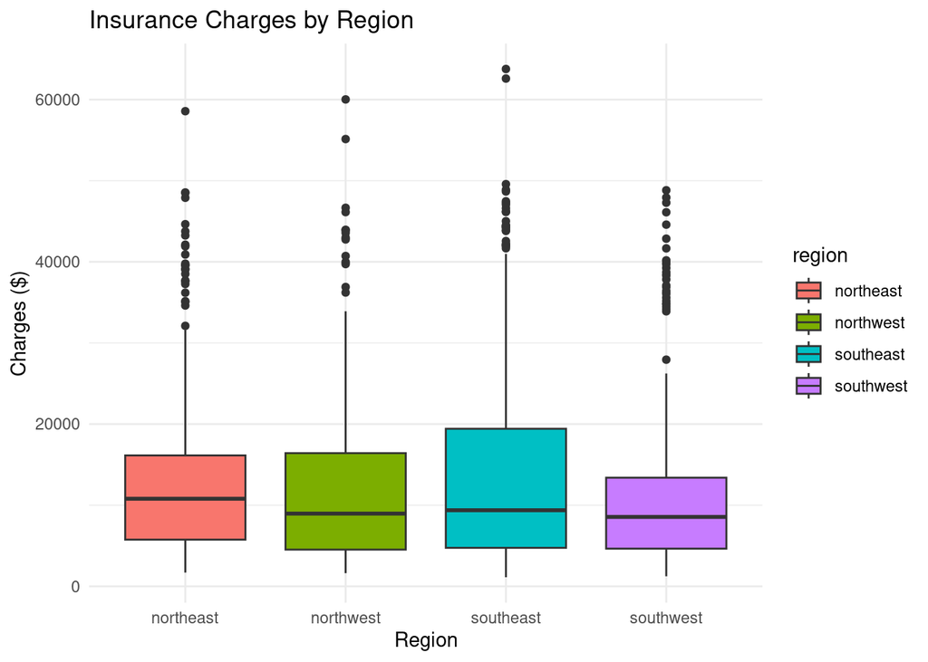

```r
# Region vs Charges
ggplot(train_data, aes(x = region, y = charges, fill = region)) +
  geom_boxplot() +
  theme_minimal() +
  labs(title = "Insurance Charges by Region",
       x = "Region",
       y = "Charges ($)")
```

Regional variations exist but are less pronounced

#### 3.2.3.3 Boxplot of Medical Charges as per children.

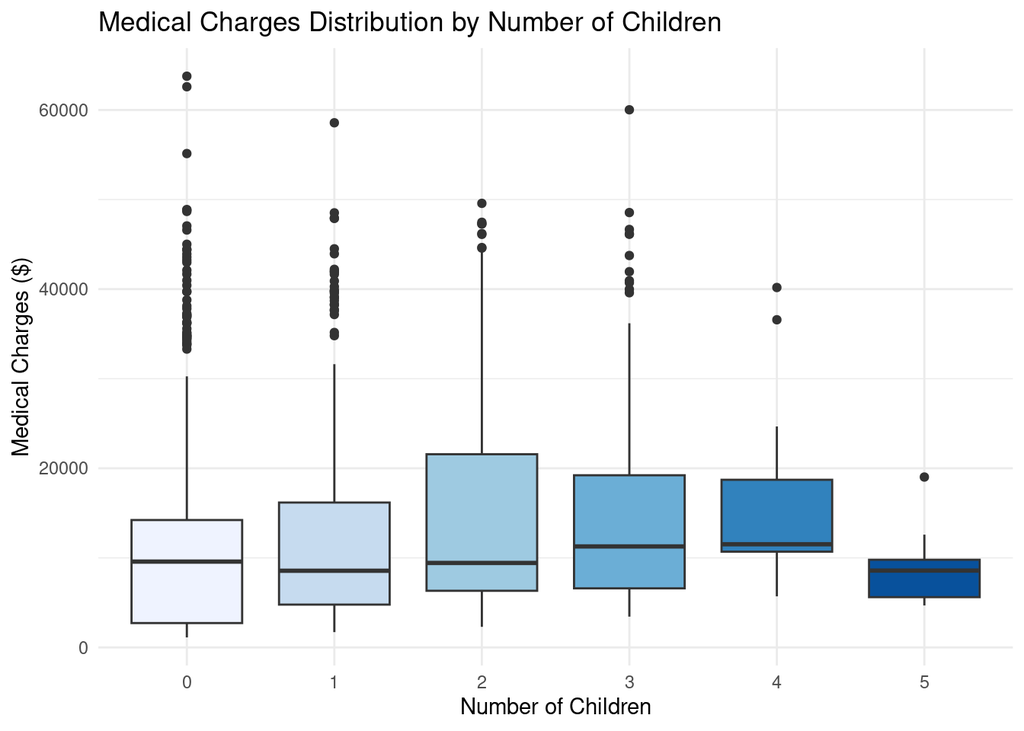

```r
# Create boxplot of medical charges by number of children
ggplot(train_data, aes(x = factor(children), y = charges, fill = factor(children))) +
  geom_boxplot() +
  theme_minimal() +
  labs(title = "Medical Charges Distribution by Number of Children",
       x = "Number of Children",
       y = "Medical Charges ($)",
       fill = "Number of Children") +
  scale_fill_brewer(palette = "Blues") +
  theme(legend.position = "none")
```

#### 3.2.3.4 Boxplot of Medical Charges as per smoker.

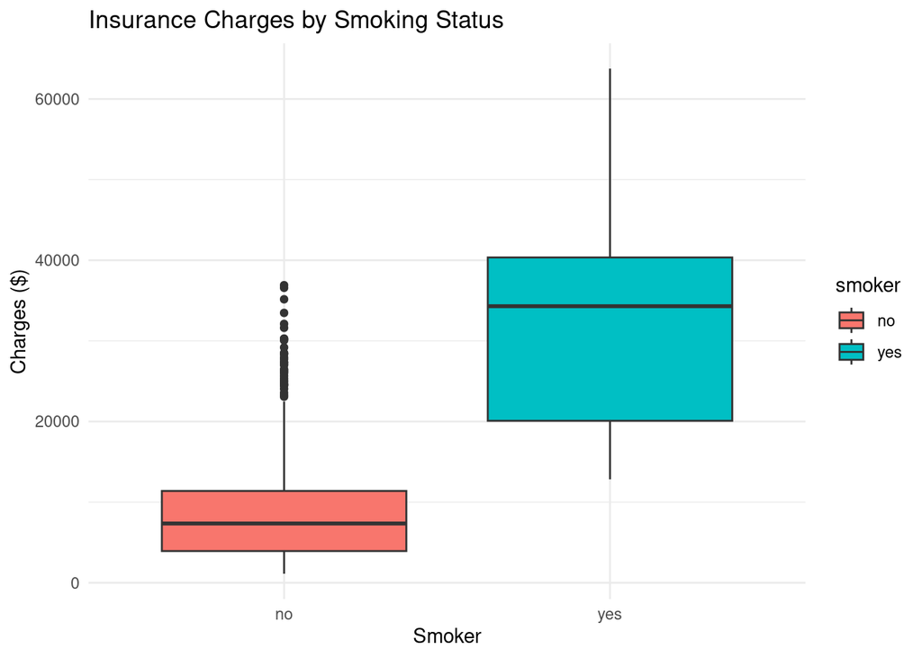

```r
# Smoker vs Charges
ggplot(train_data, aes(x = smoker, y = charges, fill = smoker)) +
  geom_boxplot() +
  theme_minimal() +
  labs(title = "Insurance Charges by Smoking Status",
       x = "Smoker",
       y = "Charges ($)")
```

**Smokers have significantly higher charges**

### 3.2.4 Create a distribution of ‘charges’ categorizing it into smoker & non-smoker. Use two separate colors for each category.

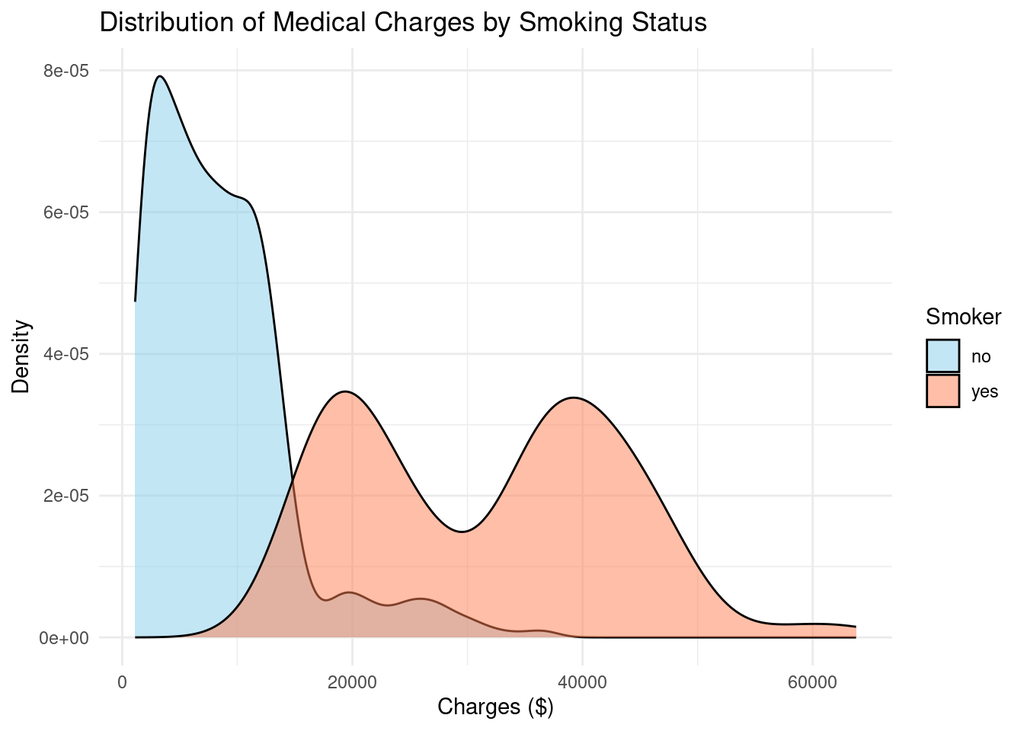

```r
# Create distribution plot of charges by smoking status
ggplot(train_data, aes(x = charges, fill = smoker)) +
  geom_density(alpha = 0.5) +
  scale_fill_manual(values = c("no" = "skyblue", "yes" = "coral")) +
  theme_minimal() +
  labs(title = "Distribution of Medical Charges by Smoking Status",
       x = "Charges ($)",
       y = "Density",
       fill = "Smoker") +
  theme(legend.position = "right")
```

```r
# Calculate summary statistics
smoker_summary <- train_data %>%
  group_by(smoker) %>%
  summarise(
    mean_charges = mean(charges),
    median_charges = median(charges),
    sd_charges = sd(charges),
    count = n()
  )
```

**Key observations from the analysis:**

Mean charges: $8,479 Median charges: $7,348 Shows a right-skewed distribution with most charges concentrated below $15,000 Smokers (n=219):

Mean charges: $31,550 Median charges: $34,303 Shows a more spread-out distribution with charges mostly between $20,000 and $45,000 Notable findings:

There’s a clear separation between smoker and non-smoker distributions Smokers’ medical charges are substantially higher (about 3.7 times) than non-smokers The variation in charges is also higher for smokers (SD: $11,554) compared to non-smokers (SD: $6,097) The distributions show minimal overlap, indicating smoking status is a strong predictor of medical charges

### 3.2.5 Create a correlation heatmap among features. Explain the plot.

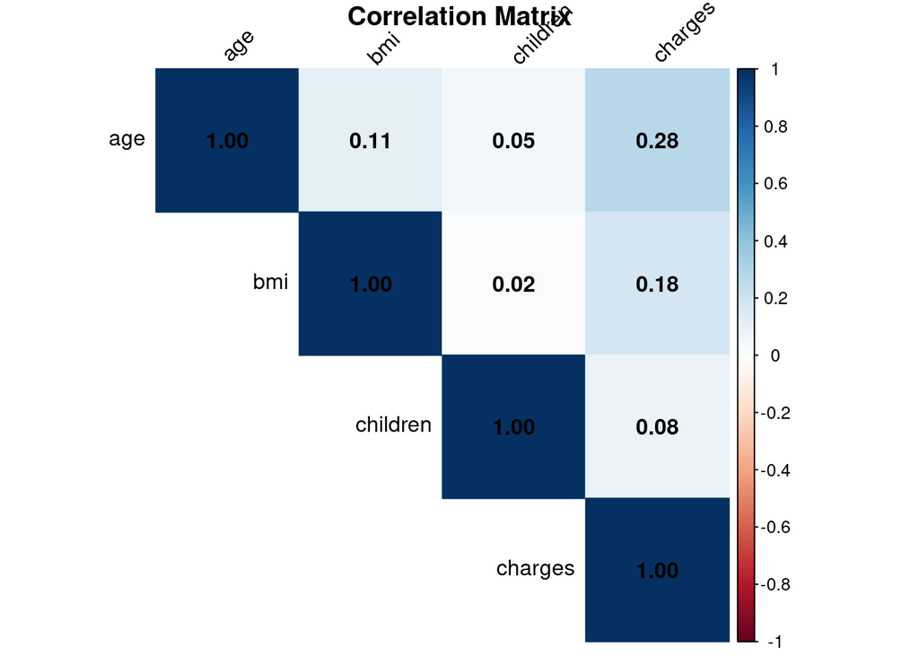

```r
# Correlation matrix for numeric variables
numeric_vars <- train_data[c("age", "bmi", "children", "charges")]
correlation_matrix <- cor(numeric_vars)
corrplot(correlation_matrix, method = "color",
         type = "upper",
         addCoef.col = "black",
         tl.col = "black",
         tl.srt = 45,
         title = "\nCorrelation Matrix")
```

The correlation heatmap shows the strongest correlation is between charges and age, while other numeric variables show weaker correlations.

## 3.3 Linear Regression Analysis [Marks 12]

### 3.3.1 Step 01: Exploring the Models. [Marks: 02]

```r
# Initial model with all predictors
full_model <- lm(charges ~ ., data = train_data)

# Perform backward elimination
best_model <- step(full_model, direction = "backward")
```

```
## Start:  AIC=18667.88
## charges ~ age + sex + bmi + children + smoker + region
##
##            Df  Sum of Sq        RSS   AIC
## - region    3 1.3678e+08 4.0476e+10 18666
## - sex       1 4.3071e+04 4.0339e+10 18666
## <none>                   4.0339e+10 18668
## - children  1 2.9468e+08 4.0633e+10 18674
## - bmi       1 4.1333e+09 4.4472e+10 18770
## - age       1 1.3330e+10 5.3669e+10 18971
## - smoker    1 9.5616e+10 1.3596e+11 19965
##
## Step:  AIC=18665.5
## charges ~ age + sex + bmi + children + smoker
##
##            Df  Sum of Sq        RSS   AIC
## - sex       1 1.2092e+05 4.0476e+10 18664
## <none>                   4.0476e+10 18666
## - children  1 2.8813e+08 4.0764e+10 18671
## - bmi       1 4.1471e+09 4.4623e+10 18768
## - age       1 1.3501e+10 5.3976e+10 18971
## - smoker    1 9.6274e+10 1.3675e+11 19965
##
## Step:  AIC=18663.5
## charges ~ age + bmi + children + smoker
##
##            Df  Sum of Sq        RSS   AIC
## <none>                   4.0476e+10 18664
## - children  1 2.8803e+08 4.0764e+10 18669
## - bmi       1 4.1517e+09 4.4627e+10 18766
## - age       1 1.3509e+10 5.3984e+10 18969
## - smoker    1 9.6514e+10 1.3699e+11 19965
```

```r
# Display summary of the best model
summary(best_model)
```

```
##
## Call:
## lm(formula = charges ~ age + bmi + children + smoker, data = train_data)
##
## Residuals:
##    Min     1Q Median     3Q    Max
## -11734  -2983  -1004   1356  29708
##
## Coefficients:
##              Estimate Std. Error t value Pr(>|t|)
## (Intercept) -11905.11    1060.63 -11.225  < 2e-16 ***
## age            254.87      13.52  18.844  < 2e-16 ***
## bmi            320.64      30.69  10.447  < 2e-16 ***
## children       429.86     156.22   2.752  0.00603 **
## smokeryes    23586.13     468.26  50.370  < 2e-16 ***
## ---
## Signif. codes:  0 '***' 0.001 '**' 0.01 '*' 0.05 '.' 0.1 ' ' 1
##
## Residual standard error: 6168 on 1064 degrees of freedom
## Multiple R-squared:  0.7359, Adjusted R-squared:  0.7349
## F-statistic: 741.3 on 4 and 1064 DF,  p-value: < 2.2e-16
```

The backward elimination process selected a model with four predictors: age, bmi, children, and smoker. The region and sex variables were eliminated as they didn’t significantly improve the model.

### 3.3.2 Step 02: Prediction. [Marks: 02]

```r
# Generate predictions on training data
train_predictions <- predict(best_model, train_data)
# Generate predictions on test data
test_predictions <- predict(best_model, test_data)

# Display sample of predictions vs actual values
head(data.frame(
  Actual = train_data$charges,
  Predicted = train_predictions,
  Difference = train_data$charges - train_predictions
))
```

```
##      Actual Predicted Difference
## 1 40182.246 33764.456  6417.7903
## 2  1137.470  3722.222 -2584.7526
## 3 38511.628 30160.651  8350.9777
## 4  4670.640  8396.975 -3726.3348
## 5 13019.161 13694.245  -675.0840
## 6  4189.113  3916.301   272.8124
```

### 3.3.3 Step 03: Evaluating Model Performance. [Marks: 03]

```r
# Calculate performance metrics for training data
train_mae <- mae(train_data$charges, train_predictions)
train_rmse <- rmse(train_data$charges, train_predictions)

# Calculate performance metrics for test data
test_mae <- mae(test_data$charges, test_predictions)
test_rmse <- rmse(test_data$charges, test_predictions)

# Create performance metrics table
metrics_df <- data.frame(
  Metric = c("Mean Absolute Error (MAE)", "Root Mean Square Error (RMSE)"),
  Training = c(train_mae, train_rmse),
  Testing = c(test_mae, test_rmse)
)
print("Model Performance Metrics:")
```

```
## [1] "Model Performance Metrics:"
```

```r
print(metrics_df)
```

```
##                          Metric Training  Testing
## 1     Mean Absolute Error (MAE) 4242.199 3941.464
## 2 Root Mean Square Error (RMSE) 6153.303 5672.102
```

### 3.3.4 Step 04: Model Evaluation. [Marks: 02]

```r
# Calculate R-squared and Adjusted R-squared
rsq <- summary(best_model)$r.squared
adj_rsq <- summary(best_model)$adj.r.squared

# Display key model statistics
model_stats <- data.frame(
  Statistic = c("R-squared", "Adjusted R-squared"),
  Value = c(rsq, adj_rsq)
)
print("Model Statistics:")
```

```
## [1] "Model Statistics:"
```

```r
print(model_stats)
```

```
##            Statistic     Value
## 1          R-squared 0.7359155
## 2 Adjusted R-squared 0.7349227
```

```r
# Display coefficients and their significance
coef_summary <- summary(best_model)$coefficients
print("
Model Coefficients:")
```

```
## [1] "\nModel Coefficients:"
```

```r
print(coef_summary)
```

```
##                Estimate Std. Error    t value      Pr(>|t|)
## (Intercept) -11905.1143 1060.62612 -11.224610  1.037851e-27
## age            254.8667   13.52489  18.844277  1.408996e-68
## bmi            320.6429   30.69280  10.446845  2.186131e-24
## children       429.8615  156.22039   2.751635  6.030582e-03
## smokeryes    23586.1314  468.26124  50.369600 5.941449e-284
```

### 3.3.5 Step 05: Checking Model Assumptions. [Marks: 03]

#### 3.3.5.1 Linearity Test

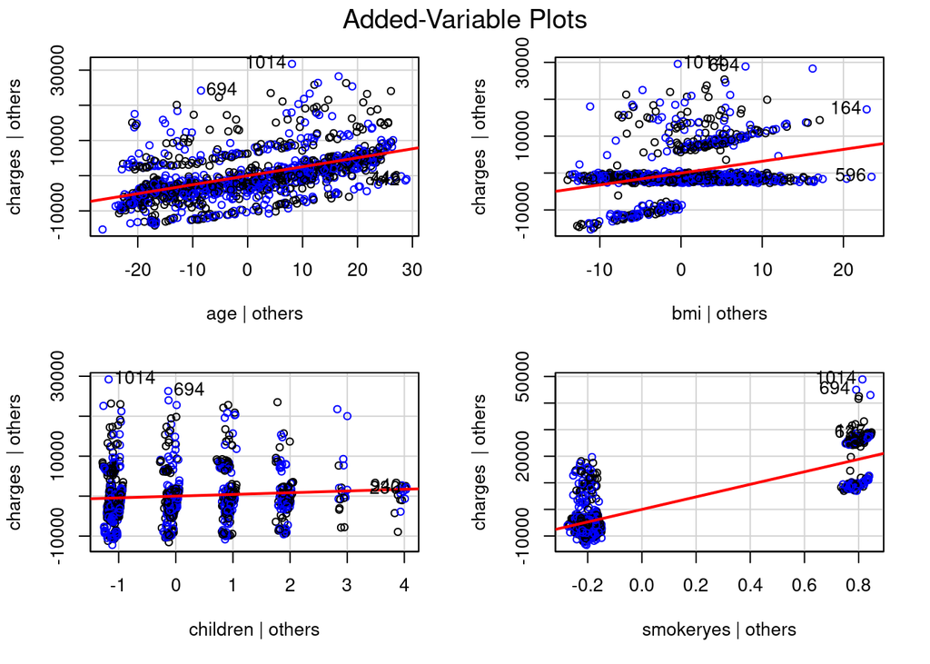

```r
# Partial regression plots
avPlots(best_model, col = c("black", "blue"), col.lines = "red")
```

#### 3.3.5.2 Residual Normality

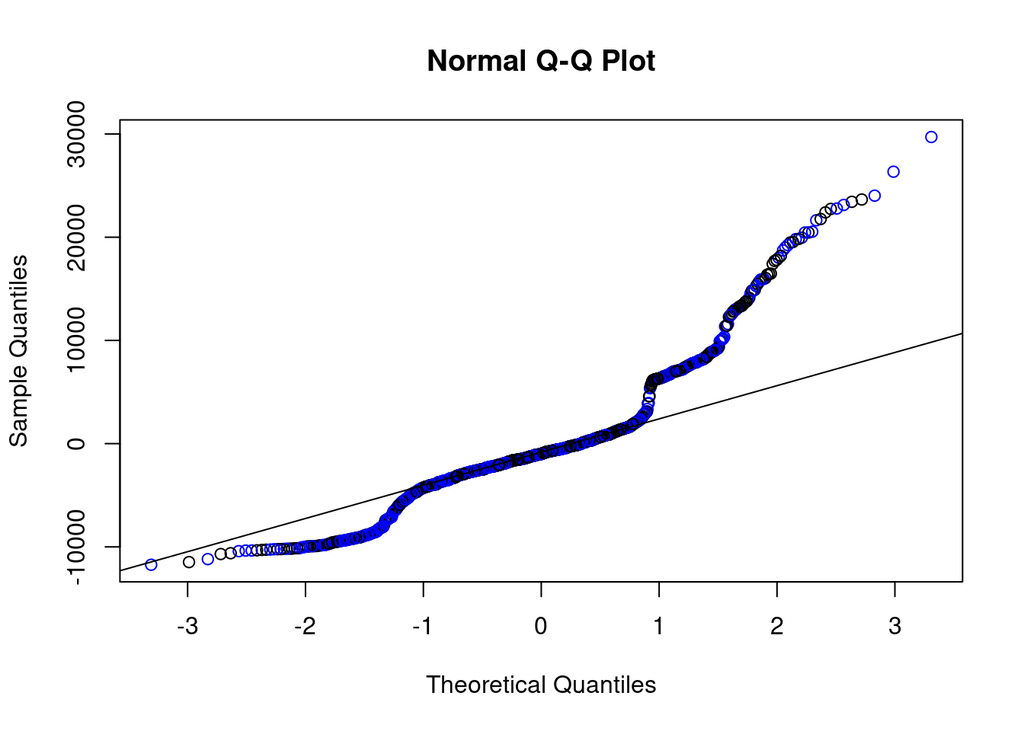

```r
# QQ plot
qqnorm(residuals(best_model),col = c("black", "blue"), col.lines = "red")
qqline(residuals(best_model))
```

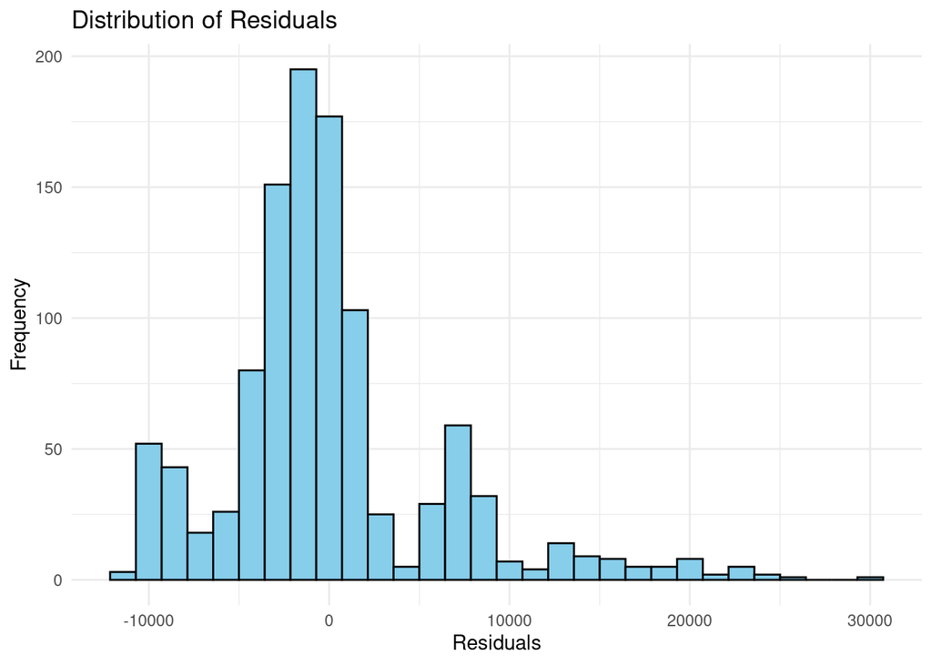

```r
# Histogram of residuals
ggplot(data.frame(residuals = residuals(best_model)), aes(x = residuals)) +
  geom_histogram(fill = "skyblue", bins = 30, color = "black") +
  theme_minimal() +
  labs(title = "Distribution of Residuals",
       x = "Residuals",
       y = "Frequency")
```

#### 3.3.5.3 Homoscedasticity

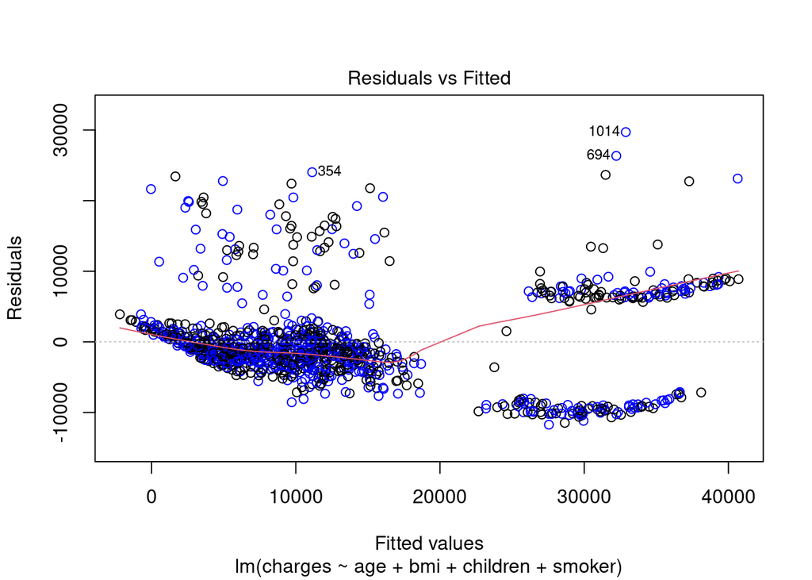

```r
# Residuals vs Fitted plot
plot(best_model, which = 1, col = c("black", "blue"), col.lines = "red")
```

#### 3.3.5.4 Multicollinearity

```r
# Calculate VIF values
vif_values <- vif(best_model)
vif_df <- data.frame(
  Variable = names(vif_values),
  VIF = vif_values
)
print("Variance Inflation Factors:")
```

```
## [1] "Variance Inflation Factors:"
```

```r
print(vif_df)
```

```
##          Variable      VIF
## age           age 1.018303
## bmi           bmi 1.013178
## children children 1.004060
## smoker     smoker 1.003712
```

# 4 Conclusions